# UNIT11C.1：多元線性回歸 Multiple Linear Regression

中山大學管理學院 卓雍然

2019-05-15 02:11:03

```r
pacman::p_load(dplyr, ggplot2, corrplot)
```

### 【A】多元線性回歸 - `lm()`

##### § A1 讀進資料

全球暖化資料集

```r
D = read.csv('data/climate_change.csv')
head(D)
```

```
  Year Month   MEI    CO2    CH4    N2O CFC.11 CFC.12    TSI Aerosols  Temp
1 1983     5 2.556 345.96 1638.6 303.68 191.32 350.11 1366.1   0.0863 0.109
2 1983     6 2.167 345.52 1633.7 303.75 192.06 351.85 1366.1   0.0794 0.118
3 1983     7 1.741 344.15 1633.2 303.80 192.82 353.73 1366.3   0.0731 0.137
4 1983     8 1.130 342.25 1631.3 303.84 193.60 355.63 1366.4   0.0673 0.176
5 1983     9 0.428 340.17 1648.4 303.90 194.39 357.46 1366.2   0.0619 0.149
6 1983    10 0.002 340.30 1663.8 303.97 195.17 359.17 1366.1   0.0569 0.093
```

分割訓練與測試資料

```r
TR = subset(D, Year <= 2006)  # Train Data
TS = subset(D, Year > 2006)   # Test Data
```

##### § A2 建立模型

- 理論模型： $y_i = \beta_0 + \beta_1 x_{1,i} + \beta_2 x_{2,i} + ... + \epsilon_i$
- 實證模型：$\hat{y}_i = b_0 + b_1 x_{1,i} + b_2 x_{2,i} + ... + e_i$
- OLS (Ordinary Least Square): 算出一組使$\Sigma_i e_i^2$最小的$b_i$

```r
m1 = lm(Temp~MEI+CO2+CH4+N2O+CFC.11+CFC.12+TSI+Aerosols,TR)
```

##### § A3 模型摘要

```r
options(digits=4, scipen=10)
summary(m1)
```

```
Call:
lm(formula = Temp ~ MEI + CO2 + CH4 + N2O + CFC.11 + CFC.12 +
    TSI + Aerosols, data = TR)

Residuals:
    Min      1Q  Median      3Q     Max
-0.2589 -0.0591 -0.0008  0.0565  0.3243

Coefficients:
               Estimate  Std. Error t value        Pr(>|t|)
(Intercept) -124.594260   19.886800   -6.27 0.0000000014310 ***
MEI            0.064205    0.006470    9.92         < 2e-16 ***
CO2            0.006457    0.002285    2.83         0.00505 **
CH4            0.000124    0.000516    0.24         0.81015
N2O           -0.016528    0.008565   -1.93         0.05467 .
CFC.11        -0.006630    0.001626   -4.08 0.0000595728765 ***
CFC.12         0.003808    0.001014    3.76         0.00021 ***
TSI            0.093141    0.014755    6.31 0.0000000010959 ***
Aerosols      -1.537613    0.213252   -7.21 0.0000000000054 ***
---
Signif. codes:  0 '***' 0.001 '**' 0.01 '*' 0.05 '.' 0.1 ' ' 1

Residual standard error: 0.0917 on 275 degrees of freedom
Multiple R-squared:  0.751, Adjusted R-squared:  0.744
F-statistic:  104 on 8 and 275 DF,  p-value: <2e-16
```

**誤差的估計** : RMSE vs. MAE

- RMSE = $\sqrt{\frac{\Sigma e_i^2}{n-2}}$
- MAE = $\frac{\Sigma |e_i|}{n}$

```r
er = m1$residuals
n = nrow(TR)
c(mean=mean(er), RMSE=sqrt(sum(er^2)/(n-2)), MAE=mean(abs(er))) %>% round(3)
```

```
 mean  RMSE   MAE
0.000 0.091 0.070
```

$y$ 的 **預測值**：

- $\hat{y} = b_0 + b_1 x_1 + b_2 x_2 + b_3 x_3 + b_4 x_4 + ...$

**簡單講**，對每一個自變數而言：

- $b_i$ : 係數的估計值代表 $x_i$ 對 $y$ 的邊際效果
- $\sigma_i$ : 係數的標準差代表該係數的不確定性
- $p_i$ : $p$-value 大致上代表 $x_i$ 與 $y_i$ 之間沒有關係的機率， 這個機率小於顯著水準，我們就說 $x_i$ 對 $y$ 的關係是顯著的

**嚴格來講**：

- 問題很多 … 整個管統、多變量、和計量經濟大概都在處理這些問題

**幸好**：

- 在商業數據分析裡面通常我們比較關心目標變數的預測值($\hat{y}$)，這部分比較沒有問題

### 【B】係數的分布(機率密度函數)

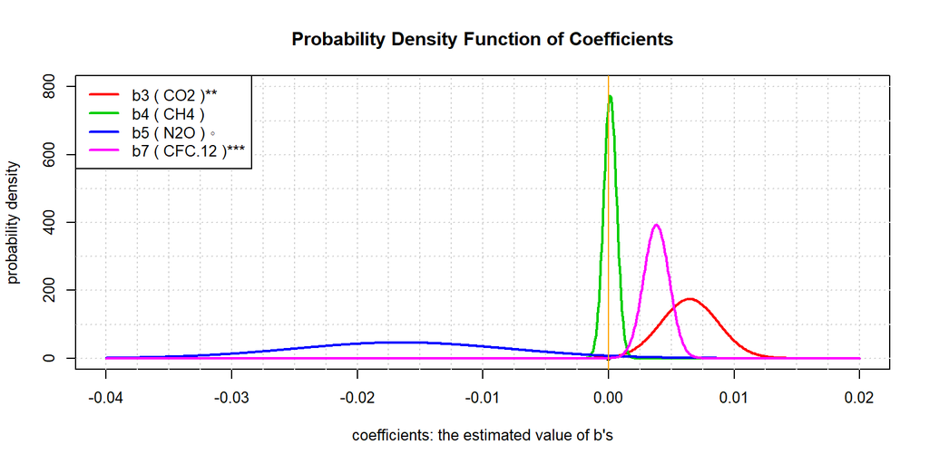

```r
vx = c(3:5,7); cx = summary(m1)$coef
par(cex=0.8)
plot(0,0,xlim=c(-0.04,0.02),ylim=c(0,800),pch=20,
     xlab="coefficients: the estimated value of b's",
     ylab='probability density',
     main='Probability Density Function of Coefficients')
abline(h=seq(0,800,100),v=seq(-0.04,0.03,0.0025),col='lightgray',lty=3)
for(i in vx) curve(dnorm(x,cx[i,1],cx[i,2]),add=T,col=i-1,lwd=2,n=1000)
abline(v=0,col='orange')
legend("topleft",col=vx-1,lwd=2,legend=paste0(
  "b",vx," ( ",rownames(cx)[vx]," )", c("**","","。","***") ) )
```

```r
summary(m1)$coef[vx,]
```

```
        Estimate Std. Error t value  Pr(>|t|)
CO2     0.006457  0.0022846  2.8264 0.0050525
CH4     0.000124  0.0005158  0.2405 0.8101456
N2O    -0.016528  0.0085649 -1.9297 0.0546693
CFC.12  0.003808  0.0010135  3.7573 0.0002097
```

🗿 討論問題：  
1.依據這個模型，在`CO2`、`CH4`、`N2O`、`CFC12`之中：  
■ 哪一種氣體的效果(關係)估計值最大？ 它的效果是顯著的嗎？  
■ 哪一種氣體的效果最顯著？ 它的效果估計值是最大的嗎？  
■ 除了係數的估計值之外，還有什麼因素會影響自變數的顯著性？  
2.如果樣本變大的話：  
■ 係數的估計值會(a)變大、(b)變小、或(c)不變？  
■ 係數的估計標準差會(a)變大、(b)變小、或(c)不變？  
■ 自變數的$p$-value會(a)變大、(b)變小、或(c)不變？  
■ 自變數的顯著性會(a)變大、(b)變小、或(c)不變？

### 【C】自變數之間的相關性、複回歸的共線性問題

自變數之間的相關性

```r
cor(TR[3:10]) %>% round(2)
```

```
           MEI   CO2   CH4   N2O CFC.11 CFC.12   TSI Aerosols
MEI       1.00 -0.04 -0.03 -0.05   0.07   0.01 -0.15     0.34
CO2      -0.04  1.00  0.88  0.98   0.51   0.85  0.18    -0.36
CH4      -0.03  0.88  1.00  0.90   0.78   0.96  0.25    -0.27
N2O      -0.05  0.98  0.90  1.00   0.52   0.87  0.20    -0.34
CFC.11    0.07  0.51  0.78  0.52   1.00   0.87  0.27    -0.04
CFC.12    0.01  0.85  0.96  0.87   0.87   1.00  0.26    -0.23
TSI      -0.15  0.18  0.25  0.20   0.27   0.26  1.00     0.05
Aerosols  0.34 -0.36 -0.27 -0.34  -0.04  -0.23  0.05     1.00
```

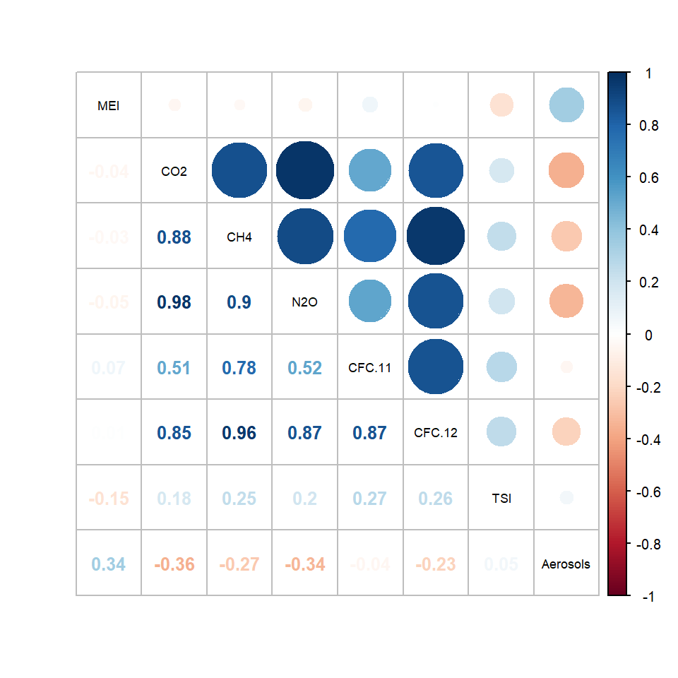

```r
cor(TR[3:10]) %>% corrplot.mixed(tl.cex=0.7, tl.col='black')
```

### 【D】模型選擇、挑選變數

##### 手動挑選自變數

```r
m2 = lm(Temp~MEI+N2O+TSI+Aerosols,TR)  #
summary(m2)
```

```
Call:
lm(formula = Temp ~ MEI + N2O + TSI + Aerosols, data = TR)

Residuals:
    Min      1Q  Median      3Q     Max
-0.2792 -0.0598 -0.0060  0.0567  0.3419

Coefficients:
              Estimate Std. Error t value         Pr(>|t|)
(Intercept) -116.22686   20.22303   -5.75 0.00000002373584 ***
MEI            0.06419    0.00665    9.65          < 2e-16 ***
N2O            0.02532    0.00131   19.31          < 2e-16 ***
TSI            0.07949    0.01488    5.34 0.00000018937322 ***
Aerosols      -1.70174    0.21800   -7.81 0.00000000000012 ***
---
Signif. codes:  0 '***' 0.001 '**' 0.01 '*' 0.05 '.' 0.1 ' ' 1

Residual standard error: 0.0955 on 279 degrees of freedom
Multiple R-squared:  0.726, Adjusted R-squared:  0.722
F-statistic:  185 on 4 and 279 DF,  p-value: <2e-16
```

##### 自動挑選自變數

```r
m3 = step(m1)   #
```

```
Start:  AIC=-1348
Temp ~ MEI + CO2 + CH4 + N2O + CFC.11 + CFC.12 + TSI + Aerosols

           Df Sum of Sq  RSS   AIC
- CH4       1     0.000 2.31 -1350
<none>                  2.31 -1348
- N2O       1     0.031 2.34 -1346
- CO2       1     0.067 2.38 -1342
- CFC.12    1     0.119 2.43 -1336
- CFC.11    1     0.140 2.45 -1333
- TSI       1     0.335 2.65 -1312
- Aerosols  1     0.437 2.75 -1301
- MEI       1     0.828 3.14 -1263

Step:  AIC=-1350
Temp ~ MEI + CO2 + N2O + CFC.11 + CFC.12 + TSI + Aerosols

           Df Sum of Sq  RSS   AIC
<none>                  2.31 -1350
- N2O       1     0.031 2.35 -1348
- CO2       1     0.067 2.38 -1344
- CFC.12    1     0.130 2.44 -1337
- CFC.11    1     0.139 2.45 -1335
- TSI       1     0.335 2.65 -1314
- Aerosols  1     0.440 2.75 -1303
- MEI       1     0.831 3.14 -1265
```

```r
summary(m3)
```

```
Call:
lm(formula = Temp ~ MEI + CO2 + N2O + CFC.11 + CFC.12 + TSI +
    Aerosols, data = TR)

Residuals:
    Min      1Q  Median      3Q     Max
-0.2577 -0.0599 -0.0010  0.0559  0.3220

Coefficients:
               Estimate  Std. Error t value        Pr(>|t|)
(Intercept) -124.515178   19.850113   -6.27 0.0000000013651 ***
MEI            0.064068    0.006434    9.96         < 2e-16 ***
CO2            0.006401    0.002269    2.82          0.0051 **
N2O           -0.016021    0.008287   -1.93          0.0542 .
CFC.11        -0.006609    0.001621   -4.08 0.0000595362634 ***
CFC.12         0.003868    0.000981    3.94          0.0001 ***
TSI            0.093116    0.014729    6.32 0.0000000010355 ***
Aerosols      -1.540206    0.212616   -7.24 0.0000000000044 ***
---
Signif. codes:  0 '***' 0.001 '**' 0.01 '*' 0.05 '.' 0.1 ' ' 1

Residual standard error: 0.0916 on 276 degrees of freedom
Multiple R-squared:  0.751, Adjusted R-squared:  0.745
F-statistic:  119 on 7 and 276 DF,  p-value: <2e-16
```

### 【E】誤差與準確性指標

- 基礎模型的差方和(**SST**)：$\sum_i (y_i-\bar{y})^2$
- 回歸模型的差方和(**SSE**)：$\sum_i (\hat{y_i}-y_i)^2$
- 判定係數($R^2$)：$1 - \frac{SSE}{SST}$
- 均方差(**RMSE**)：$\sqrt{SSE/(n-2)}$ Residual Standard Error

##### § E1 使用 **訓練資料** 做預測和估計準確度

```r
pred =  predict(m3)                     #
SSE = sum((pred - TR$Temp)^2)           # SSE.train
SST = sum((mean(TR$Temp) - TR$Temp)^2)  # SST.train
R2 = 1 - SSE/SST                        # R2.train
RMSE = sqrt(SSE/nrow(TR))               # RMSE.train
c(SSE, SST, R2, RMSE)
```

```
[1] 2.31351 9.28526 0.75084 0.09026
```

##### § E2 使用 **測試資料** 做預測和估計準確度

```r
pred =  predict(m3, TS)                 #
SSE = sum((pred - TS$Temp)^2)           # SSE.test
SST = sum((mean(TR$Temp) - TS$Temp)^2)  # SST.test
R2 = 1 - SSE/SST                        # R2.test
RMSE = sqrt(SSE/nrow(TS))               # RMSE.test
c(SSE, SST, R2, RMSE)
```

```
[1] 0.21764 0.58602 0.62861 0.09523
```

注意一下，我們計算 **測試資料** 的差方和是使用 **訓練資料** 的平均值做基準

$$SST_{test} = \sum_{i=1}^n(\bar{y}_{train} - y_{i,test})^2$$
所以 $R_{test}^2$ 有可能會小於零。

🗿 討論問題：  
3.在商務數據分析的角度，我們應該關心的是自變數的：  
■ 係數估計值  
■ $p$-value  
■ 顯著性  
■ 其他，請說明為甚麼？